# caoston-2

Hussin. Almustafa

2022-10-07

# *Medical Cost Personal Dataset*

# Introduction :

For this project, I will be applying machine learning techniques on the/ Medical Cost Personal Dataset/The data are downloadable from [The link to the data set](https://www.kaggle.com/datasets/mirichoi0218/insurance/download?datasetVersionNumber=1)

the data explain the cost of a small sample of USA population Medical Insurance Cost based on some attributes depicted on “Content”.[my github repo](https://github.com/halmustafa/Capston-/tree/master)

*the Goal of the project :* The purpose of this project is to predict the medical expenses .

# Methods:

after downloading the data i,m going to explore it, extract the Information from it , and cleaning the data ,then prepare the data for analysis ,Visualization ,then start Training and resampling several models.

##1-data loding:

```r
library(glmnet)
library(dplyr)
library(caretEnsemble)
library(kernlab)
library(tidyverse)
library(reshape2)
library(RColorBrewer)
library(data.table)
library(caret)
```

# 2- Data Exploration:

```r
set.seed(123)
##Reading Data
dat <- read.csv("C:/Users/Almustafa/Documents/med.csv")

str(dat)
```

```
## 'data.frame':    1338 obs. of  7 variables:
##  $ age     : int  19 18 28 33 32 31 46 37 37 60 ...
##  $ sex     : chr  "female" "male" "male" "male" ...
##  $ bmi     : num  27.9 33.8 33 22.7 28.9 ...
##  $ children: int  0 1 3 0 0 0 1 3 2 0 ...
##  $ smoker  : chr  "yes" "no" "no" "no" ...
##  $ region  : chr  "southwest" "southeast" "southeast" "northwest" ...
##  $ charges : num  16885 1726 4449 21984 3867 ...
```

we can see the data is a data frame with 1338 observations and 7 variables, the variable - charges - as response variable

### The column descriptions look like this:

age: age of primary beneficiary

sex: female, male

bmi: Body mass index, providing an understanding of body, weights that are relatively high or low relative to height, objective index of body weight (kg / m ^ 2)

children: Number of children

smoker: Smoking Yes or No

region: the beneficiary’s residential area in the US . charges: Individual medical costs billed by health insurance.

## check the summary of variables :

```r
summary(dat)
```

```
##       age            sex                 bmi           children
##  Min.   :18.00   Length:1338        Min.   :15.96   Min.   :0.000
##  1st Qu.:27.00   Class :character   1st Qu.:26.30   1st Qu.:0.000
##  Median :39.00   Mode  :character   Median :30.40   Median :1.000
##  Mean   :39.21                      Mean   :30.66   Mean   :1.095
##  3rd Qu.:51.00                      3rd Qu.:34.69   3rd Qu.:2.000
##  Max.   :64.00                      Max.   :53.13   Max.   :5.000
##     smoker             region             charges
##  Length:1338        Length:1338        Min.   : 1122
##  Class :character   Class :character   1st Qu.: 4740
##  Mode  :character   Mode  :character   Median : 9382
##                                        Mean   :13270
##                                        3rd Qu.:16640
##                                        Max.   :63770
```

we can see that there is a difference between mean & median in the variable charges

##Let’s see the distribution of charges

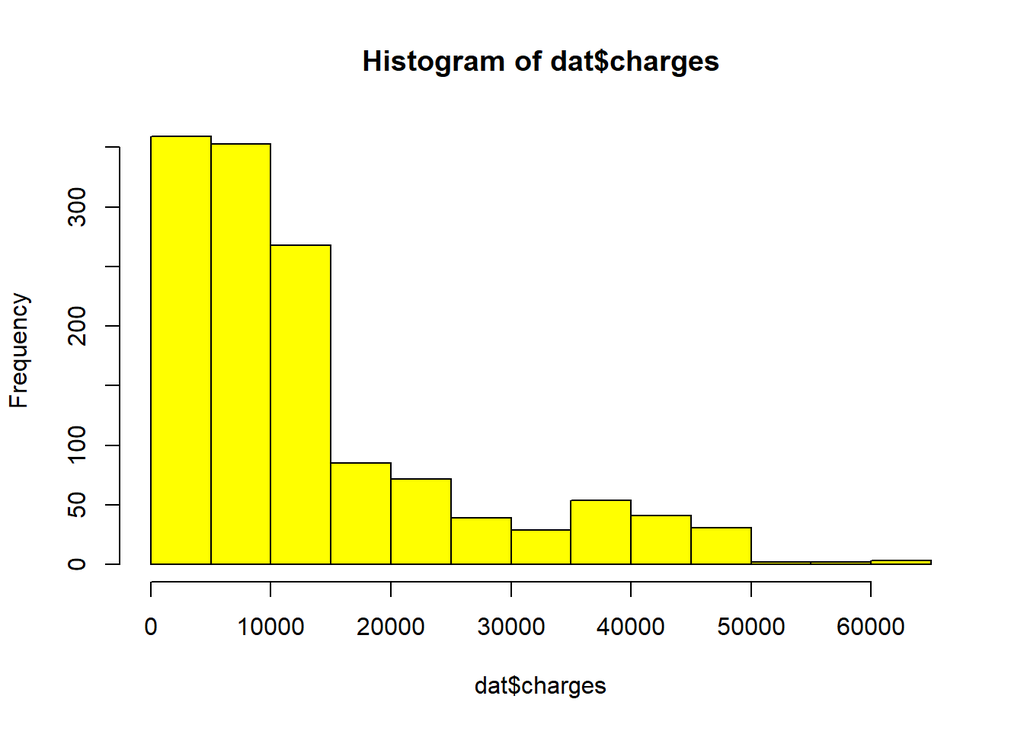

```r
hist(dat$charges,col = "yellow")
```

the plot shows that the majority of people in our data have yearly medical expenses between 0 - 15,000$ .

# look at the categorical variable distribution:

```r
table(dat$sex)
```

```
##
## female   male
##    662    676
```

```r
table(dat$smoker)
```

```
##
##   no  yes
## 1064  274
```

```r
table(dat$region)
```

```
##
## northeast northwest southeast southwest
##       324       325       364       325
```

*find the relationship among variables*

```r
cor(dat[c("age","bmi","children","charges")])
```

```
##                age       bmi   children    charges
## age      1.0000000 0.1092719 0.04246900 0.29900819
## bmi      0.1092719 1.0000000 0.01275890 0.19834097
## children 0.0424690 0.0127589 1.00000000 0.06799823
## charges  0.2990082 0.1983410 0.06799823 1.00000000
```

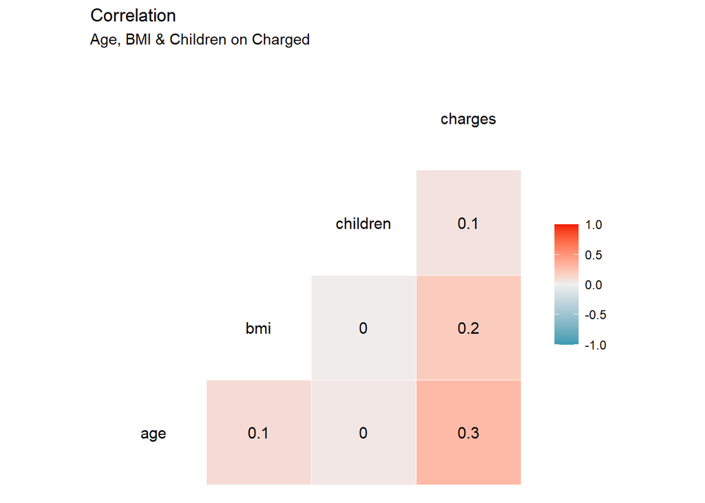

```r
library(ggplot2)
library(GGally)
ggcorr(dat, label = T, color = "black", size = 4)+
  labs(title = "Correlation ",
       subtitle = "Age, BMI & Children on Charged ")
```

the plot shows that age has the highest correlation with charges

# 3- data cleaning :

```r
library(janitor)
sum(is.na(dat))
```

```
## [1] 0
```

there is no Na in our data,

removing empty rows and col,s:

```r
dat <-dat %>% remove_empty(whic=c("rows"))
dat <-dat %>% remove_empty(whic=c("cols"))
```

# data visualisation :

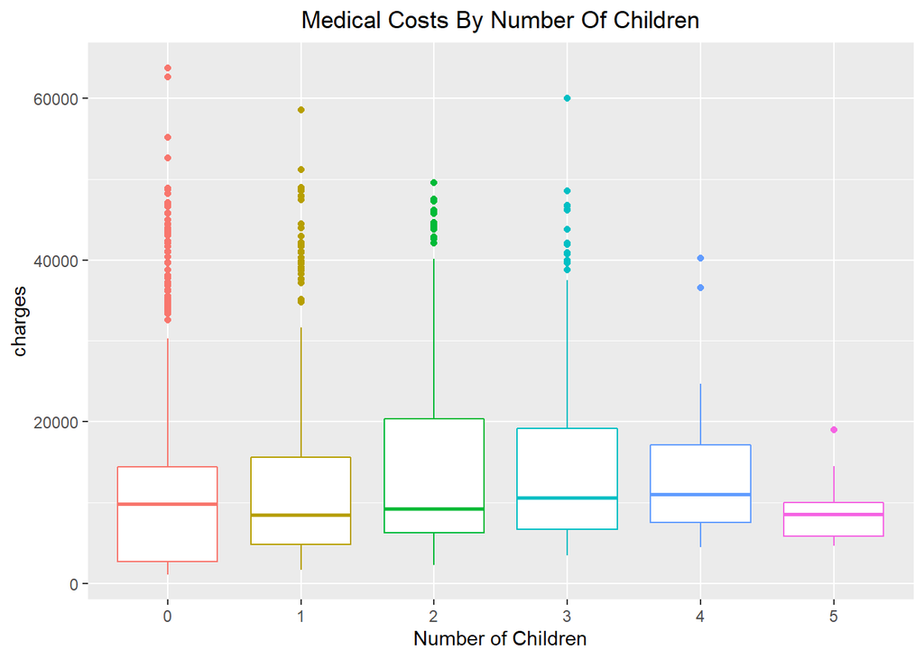

```r
ggplot(dat, aes(x = as.factor(children), y = charges, color = as.factor(children))) +
  geom_boxplot() +
  labs(title = "Medical Costs By Number Of Children",
      x = "Number of Children") +
    theme(plot.title = element_text(hjust = 0.5),
          legend.position = "none")
```

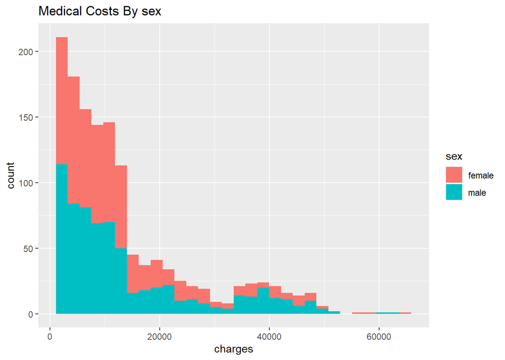

```r
   dat%>%
  ggplot(aes(charges,fill=sex,binwidth=30))+
  geom_histogram()+
  labs(title = "Medical Costs By sex")
```

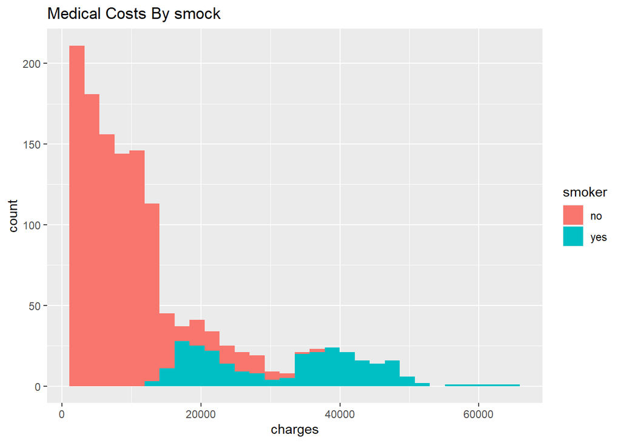

```r
  dat%>%
  ggplot(aes(charges,fill=smoker, binwidth=30))+
  geom_histogram()+
  labs(title = "Medical Costs By smock")
```

Smokers have more charges than non-smokers.

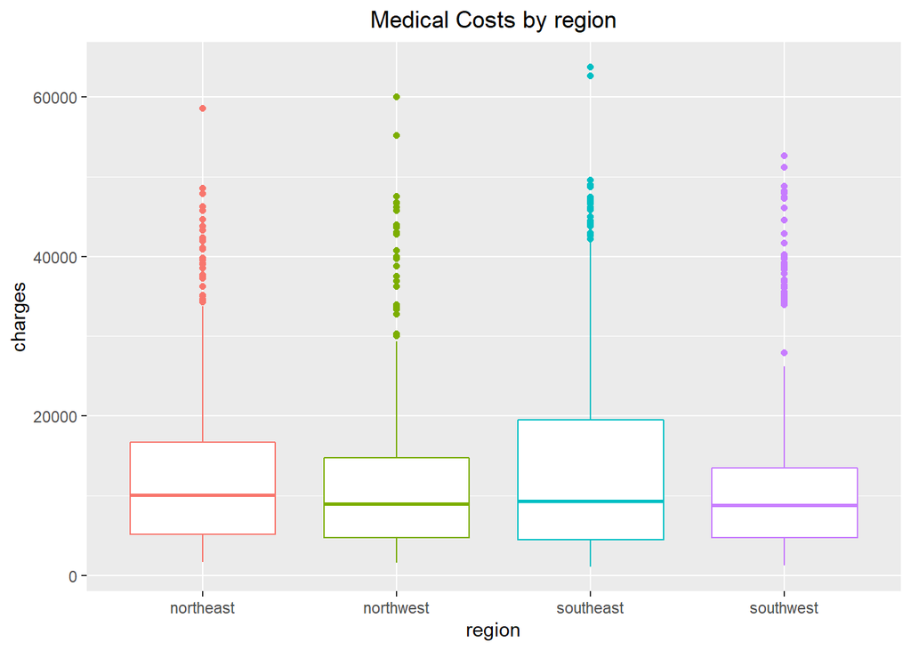

```r
ggplot(dat, aes(x = as.factor(region), y = charges, color = as.factor(region))) +
  geom_boxplot() +
  labs(title = "Medical Costs by region",
      x = "region") +
    theme(plot.title = element_text(hjust = 0.5),
          legend.position = "none")
```

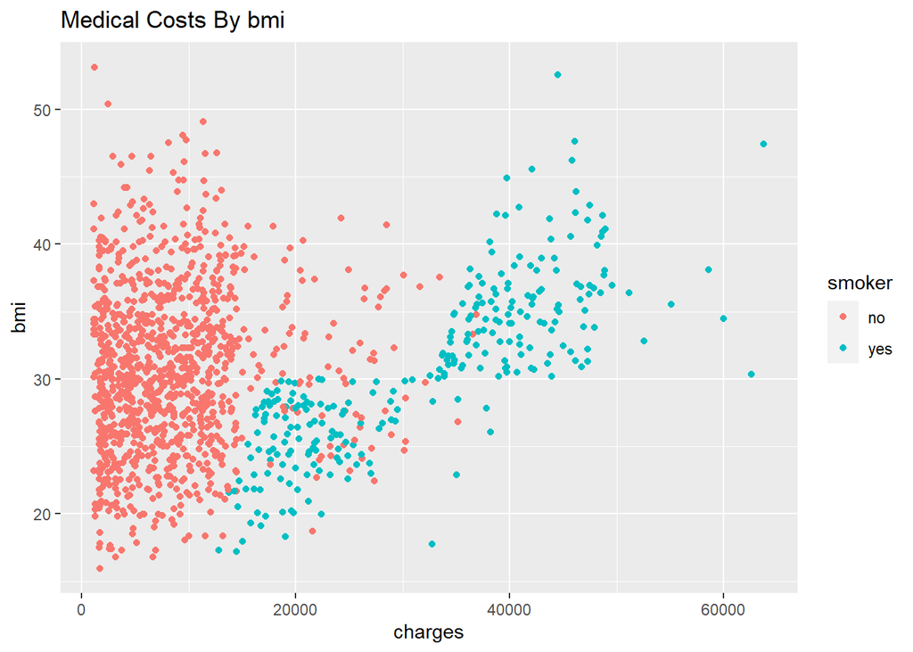

```r
 dat%>%
  ggplot(aes(charges,bmi,color= smoker,fill=smoker))+
  geom_point()+
  labs(title = "Medical Costs By bmi")
```

# modeling :

```r
library(caret)
set.seed(2002)
y<- dat$charges

test_index <- createDataPartition(y, times = 1, p = 0.2, list = FALSE)

dat_train <- dat %>% slice(-test_index)
dat_test <- dat  %>% slice(test_index)
```

# model-1 Linear Regression:

```r
m <- mean(dat_train$charges)
m
```

```
## [1] 13251.17
```

Our root mean squared error is:

```r
sqrt(mean((m - dat_test$charges)^2))
```

```
## [1] 12351.59
```

using the function lm()To fit a linear regression model to data

```r
fit <- lm(charges~ ., data = dat_train)
fit$coef
```

```
##     (Intercept)             age         sexmale             bmi        children
##     -12396.0881        256.8043       -374.6309        354.1554        469.4450
##       smokeryes regionnorthwest regionsoutheast regionsouthwest
##      23742.9607       -118.3729      -1093.7706       -704.4017
```

```r
 y_hat <- predict(fit, dat_test)
sqrt(mean((y_hat - dat_test$charges)^2))
```

```
## [1] 6024.599
```

We can see that this does indeed provide an improvement over our guessing approach.

## model-2 Random Forest :

```r
rf <- train(charges ~., data = dat_train, method = "rf")
rf
```

```
## Random Forest
##
## 1070 samples
##    6 predictor
##
## No pre-processing
## Resampling: Bootstrapped (25 reps)
## Summary of sample sizes: 1070, 1070, 1070, 1070, 1070, 1070, ...
## Resampling results across tuning parameters:
##
##   mtry  RMSE      Rsquared   MAE
##   2     5345.568  0.8306883  3673.149
##   5     4894.491  0.8326070  2761.640
##   8     5106.759  0.8192830  2884.123
##
## RMSE was used to select the optimal model using the smallest value.
## The final value used for the model was mtry = 5.
```

*Variable importance plot from random forest*

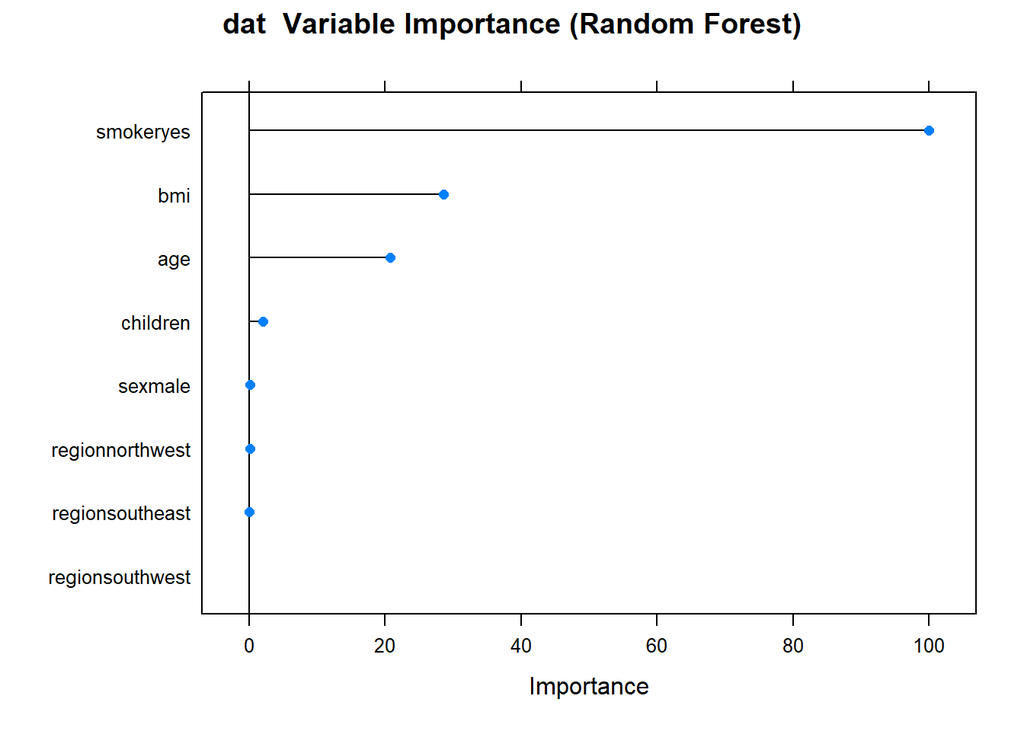

```r
varimp_RF <- varImp(rf)
plot(varimp_RF, main = "dat  Variable Importance (Random Forest)")
```

we use the random forest to predict on our test data.

```r
fit <- predict(rf,dat_test)
fit[1:8]
```

```
##         1         2         3         4         5         6         7         8
##  9065.898  3360.915  2727.388  4193.344 14689.996 37739.937  4264.770  5125.904
```